# Evaluación curso R

Hana Cermakova

## Entrega

- Recuerda completar tu **nombre en el apartado author**.
- Además del código, no olvides completar las respuestas a las preguntas indicadas en negrita.
- Si tienes dudas/dificultades, **puedes contactar con los profesores**.
- Deadline: **24-06-2026**
- Puedes realizar la entrega en el mail: **constantino.garciama@ceu.es**.
- La entrega consistirá en el fichero que se genera al hacer `Knit` (un fichero `html` o `pdf`).

## Apuestas de adolescentes en UK

El conjunto de datos `teengamb.csv` contiene datos sobre las tasas de juego entre los adolescentes en Gran Bretaña, su género y estatus socioeconómico. Una pregunta que nos puede interesar es **si los ingresos del adolescente y su sexo influyen en la cantidad de dinero apostado (céntrate solo en las variables `income`, `sex` y `gamble`)** … Sigue los siguientes pasos para crear un ANCOVA…

### 1a) Carga los datos…

```r
teengamp = read.csv(file = "teengamb.csv", sep = ",")
teengamp$sex = factor(teengamp$sex)
head(teengamp)
```

```
##      sex status income verbal     gamble
## 1 Female     51   2.00      8  20.965805
## 2 Female     28   2.50      8 -11.091514
## 3 Female     37   2.00      6  -8.586763
## 4 Female     28   7.00      4  17.351732
## 5 Female     65   2.00      8 -17.252409
## 6 Female     61   3.47      6  14.878533
```

### 1b) Visualiza los datos…

…para valorar si el modelo debe incluir interacciones. Para ello, escribe el código que genera una gráfica similar a la siguiente:

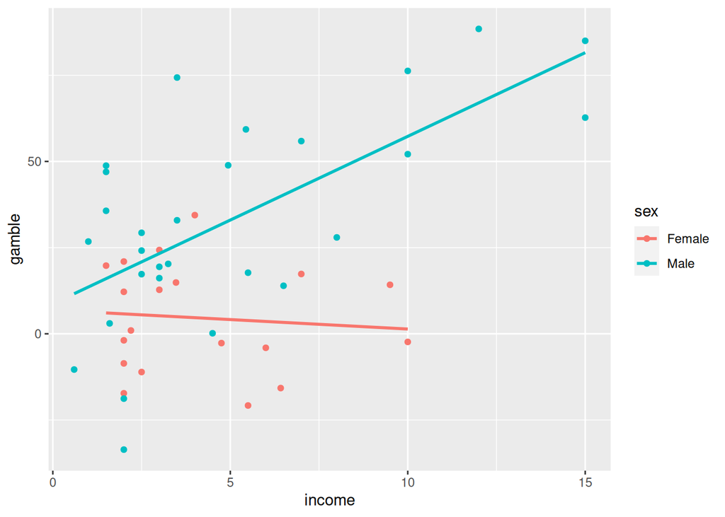

```r
library("tidyverse")
```

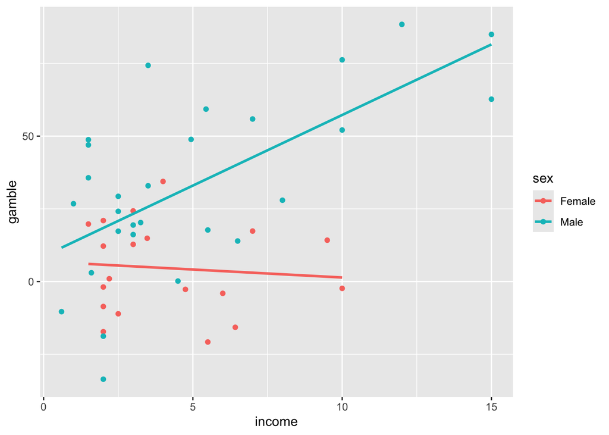

```r
ggplot(teengamp, aes(x = income, y=gamble, col = sex)) +
      geom_point()+
      geom_smooth(method = "lm", se = FALSE)+
        labs(x="income",y="gamble")
```

La gráfica anterior apoya que hay interacciones entre las variables `sex` e `income`. **Explica los motivos brevemente** (Pista: ¿son las rectas paralelas?)

EL modelo LM crea rectas que no son paralelas, por lo cual hay que crear un modelo con interacciones entre sexo y ingresos

### 2) Crea el modelo…

… y obtén los intervalos de confianza para los coeficientes y su significación.

```r
gamb_model = lm(gamble ~ income * sex, data = teengamp)

summary(gamb_model)
```

```
##
## Call:
## lm(formula = gamble ~ income * sex, data = teengamp)
##
## Residuals:
##     Min      1Q  Median      3Q     Max
## -52.025 -15.479  -3.559  14.022  48.625
##
## Coefficients:
##                Estimate Std. Error t value Pr(>|t|)
## (Intercept)      6.8743     9.2446   0.744   0.4612
## income          -0.5489     1.9024  -0.289   0.7743
## sexMale          1.8427    11.1946   0.165   0.8700
## income:sexMale   5.4050     2.1435   2.522   0.0155 *
## ---
## Signif. codes:  0 '***' 0.001 '**' 0.01 '*' 0.05 '.' 0.1 ' ' 1
##
## Residual standard error: 20.97 on 43 degrees of freedom
## Multiple R-squared:  0.5105, Adjusted R-squared:  0.4764
## F-statistic: 14.95 on 3 and 43 DF,  p-value: 8.279e-07
```

```r
  #                 Estimate Std. Error t value Pr(>|t|)
  #(Intercept)      6.8743     9.2446   0.744   0.4612   <-base mujer (income=0)
  #income          -0.5489     1.9024  -0.289   0.7743   <-influencia de income en mujeres
  #sexMale          1.8427    11.1946   0.165   0.8700   <-diferencia en intercepto para hombres
  #income:sexMale   5.4050     2.1435   2.522   0.0155 * <-diferencia en pendiente para hombres

confint(gamb_model)
```

```
##                     2.5 %    97.5 %
## (Intercept)    -11.769152 25.517839
## income          -4.385455  3.287728
## sexMale        -20.733425 24.418773
## income:sexMale   1.082260  9.727751
```

```r
  #                    2.5 %    97.5 %
  #(Intercept)    -11.769152 25.517839
  #income          -4.385455  3.287728
  #sexMale        -20.733425 24.418773
  #income:sexMale   1.082260  9.727751
```

### 3) Valora si las asunciones del modelo se cumplen

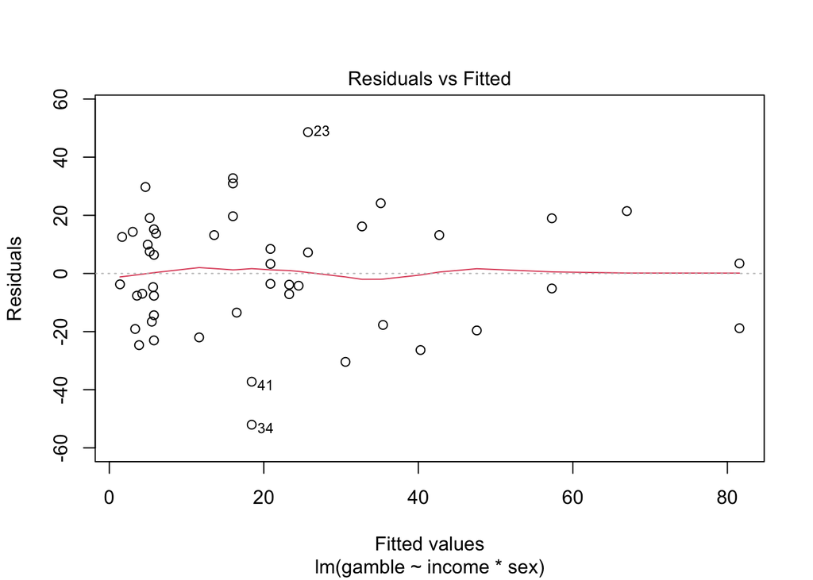

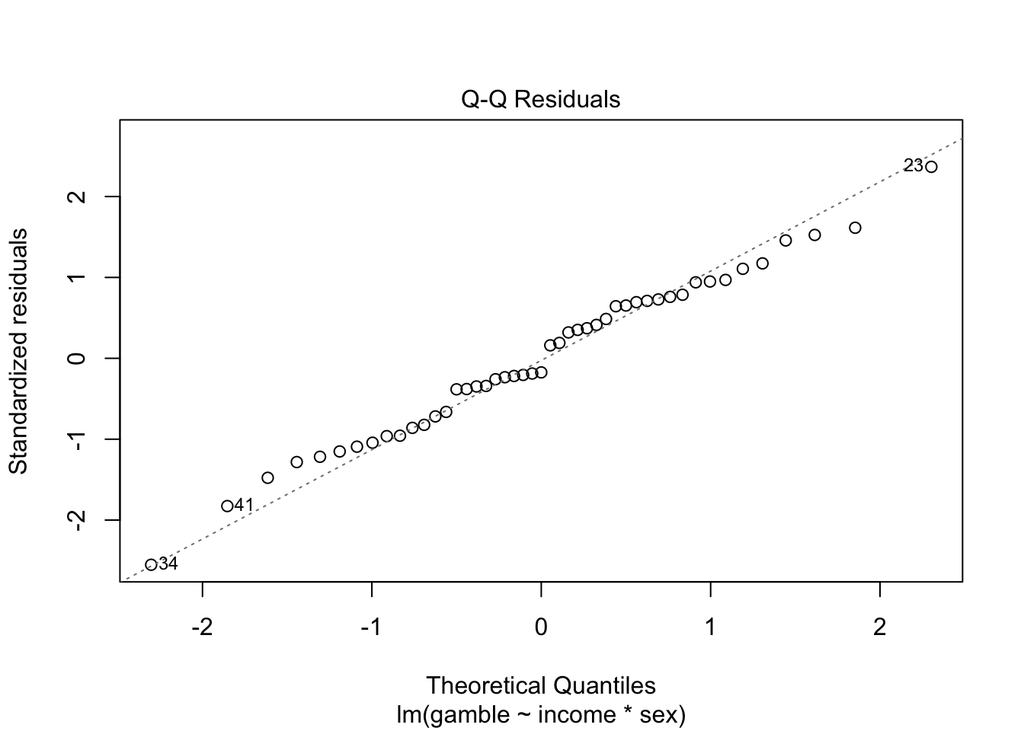

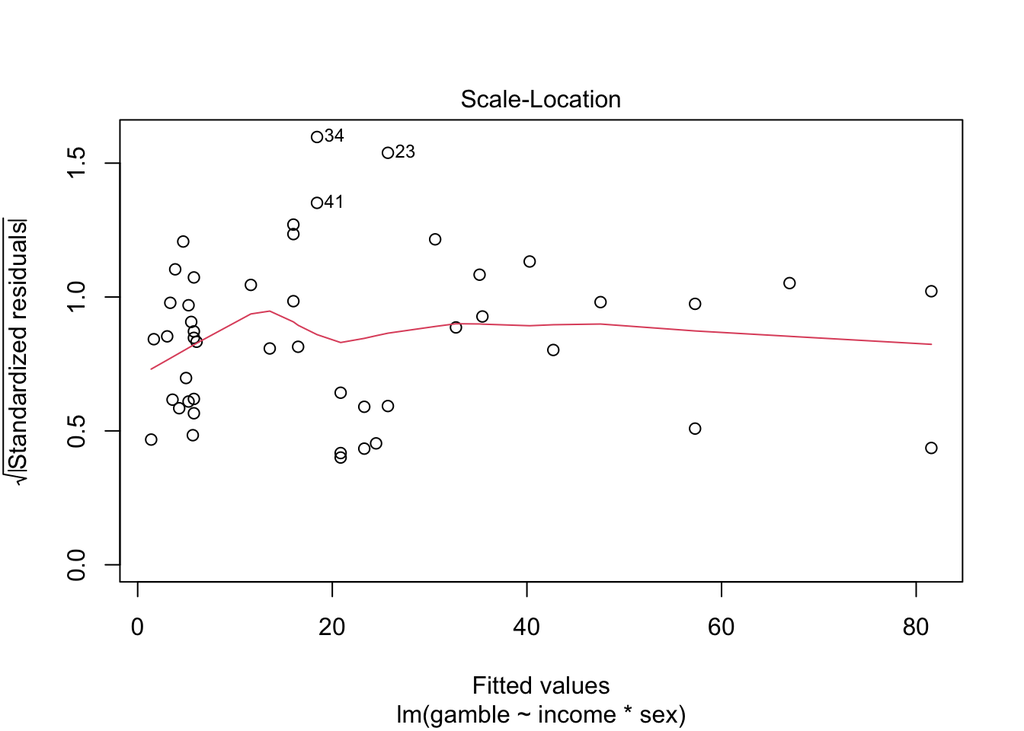

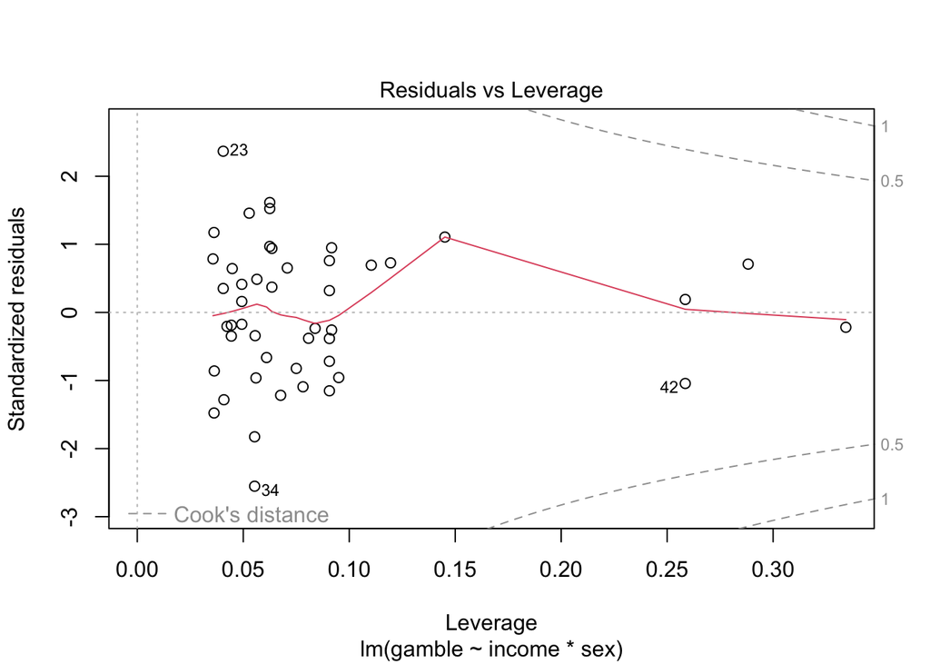

```r
# Interpretar las 4 gráficas siguientes para decidir si las asunciones del modelo
# se cumplen
plot(gamb_model, ask = FALSE)
```

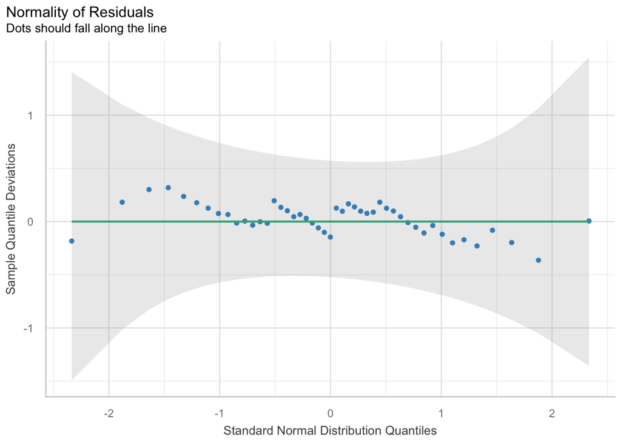

```r
  # 1) Residuals vs Fitted - línea cercana a cero sin patrones sistemáticos, los residuales se distribuyen de forma homogénea a lo largo de los distintos valores ajustados.--> OK
  # 2) Q-Q Residuals - evaluar con library("performance")
  # 3) Scale Location - la varianza de los residuales se mantiene constante a lo largo de los valores ajustados, con valores comprendidos entre 0 y 1.5 y una línea aproximadamente plana. Esto indica ausencia de heterocedasticidad y outliers.--> OK
  # 4) Residuals vs Leverage -todas las observaciones se encuentran dentro de los límites marcados por la distancia de Cook, lo que indica que ningún punto ejerce una influencia excesiva sobre las estimaciones del modelo.--> OK

library("performance")
is_norm = check_normality(gamb_model)
plot(is_norm, type = "qq")
```

```r
  # 2) Q-Q Residuals - residuales siguen una distribución normal, el supuesto de normalidad del modelo lineal se cumple satisfactoriamente.. --> OK
```

**¿Es el modelo correcto?:** SI

### 4) Interpreta los coeficientes y escribe tus conclusiones.

De la tabla de p-valores, podemos concluir que para las mujeres:
$$gambling = 6.87 - 0.5489 * income$$
Mientras que para hombres:
$$gambling
= 8.72 + 4.8561 * income.$$
Fíjate que el coeficiente -0.5489 no es significativo, mientras que el salto en las pendientes entre mujeres y hombres es de 5.4050 y sí es significativo.

**¿Cuáles de las siguientes conclusiones son correctas? (puede haber varias)**

1. Los hombres y mujeres adolescentes apuestan de la misma forma. **FALSO**. La interaccion income:sexMale es significativa, lo cual significa que el efecto de ingresos sobre apuestas es diferente entre sexos.
2. No hay evidencia suficiente de que las mujeres apuesten de forma diferente según sus ingresos. **CORRECTO** la variable income para mujeres no es significativa, por lo cual no hay evidencia suficiente para concluir que el efecto sea distinto de cero.
3. Para los hombres: a mayor nivel de ingresos, mayor cantidad apostada. **CORRECTO** La pendiente para hombres es positiva y significativa.

```r
contrasts(teengamp$sex)
```

```
##        Male
## Female    0
## Male      1
```

```r
teengamp$sex = relevel(teengamp$sex, "Male")
gamb_model_2 = lm(gamble ~ income * sex, data = teengamp)
summary(gamb_model_2)
```

```
##
## Call:
## lm(formula = gamble ~ income * sex, data = teengamp)
##
## Residuals:
##     Min      1Q  Median      3Q     Max
## -52.025 -15.479  -3.559  14.022  48.625
##
## Coefficients:
##                  Estimate Std. Error t value Pr(>|t|)
## (Intercept)        8.7170     6.3132   1.381   0.1745
## income             4.8561     0.9876   4.917 1.33e-05 ***
## sexFemale         -1.8427    11.1946  -0.165   0.8700
## income:sexFemale  -5.4050     2.1435  -2.522   0.0155 *
## ---
## Signif. codes:  0 '***' 0.001 '**' 0.01 '*' 0.05 '.' 0.1 ' ' 1
##
## Residual standard error: 20.97 on 43 degrees of freedom
## Multiple R-squared:  0.5105, Adjusted R-squared:  0.4764
## F-statistic: 14.95 on 3 and 43 DF,  p-value: 8.279e-07
```

```r
 #                 Estimate Std. Error t value Pr(>|t|)
 #(Intercept)        8.7170     6.3132   1.381   0.1745
 #income             4.8561     0.9876   4.917 1.33e-05 ***
 #sexFemale         -1.8427    11.1946  -0.165   0.8700
 #income:sexFemale  -5.4050     2.1435  -2.522   0.0155 *
confint(gamb_model_2)
```

```
##                       2.5 %    97.5 %
## (Intercept)       -4.014845 21.448880
## income             2.864485  6.847797
## sexFemale        -24.418773 20.733425
## income:sexFemale  -9.727751 -1.082260
```

```r
  #                      2.5 %    97.5 %
  #(Intercept)       -4.014845 21.448880
  #income             2.864485  6.847797
  #sexFemale        -24.418773 20.733425
  #income:sexFemale  -9.727751 -1.082260
```

4. La diferencia entre las pendientes de hombres y mujeres no es significativa. **FALSO** la interaccion income:sexMale, que representa la diferencia de pendiente entre hombres y mujeres es significativa, IC [1.082260 9.727751]